# Análise CBR - Protótipo

Protótipo da Análise de CBA probabilística. Vamos carregar as funções de CBA do arquivo cba.R, e o pacote para estimar uma distribuição dos dados simulados.

```r
# Análise de Custo Benefício
library(fitdistrplus)
# Carregando arquivos com Funções
source("financial_functions.R")
source("cba.R")
```

Agora vamos definir o período de análise e chamar a função para calculo do CBA.

Vamos definir um custo e benefício normalmente distribuído ano a ano, com médias e desvios padrão abaixo. Vamos replicar esta função 100 vezes e salvar os resultados

```r
## Primeiro teste para rodar uma análise de custo benefício probabilística
### Parâmetros para Rodar a Análise
#Número de Períodos a Analisar e Ano Inicial
n = 10
initial_year = 2017
### Rodando a Análise CBA 200 vezes
cba_replications = replicate(n=100,
                             cba_analysis(mean_cost=30,
                                          sd_cost=5,
                                          mean_benefit=30,
                                          sd_benefit=10)
                             )
```

Agora vamos separar as replicações em vetores específicos

```r
# Separando os resultados em vetores diferentes
# vendo o VPL
vpl = cba_replications[1,]
# retornando o CBR
cbr = cba_replications[2,]
# retornando o ROI
roi = cba_replications[3,]
```

Cada um dos itens do vetor possui o resultado de uma simulação específica do VPL, CBR e ROI respectivamente.

Esse são os dados do VPL…

```r
vpl
```

```
  [1] -21.5958703 -36.4914595  38.7184909  19.0680143   5.0661423 -20.1785206
  [7]   2.5161324  -3.7623355 -67.0447200   8.7447656 -20.8433463 -72.3776822
 [13]   3.2002521   4.8403020 -72.3116561   5.4792336 -33.2930313 -11.6705755
 [19]  31.1351679  14.5538347   5.2422740 -28.9233793   2.5661919 -30.4055771
 [25] -26.9198154  -5.6149852 -18.3028532  43.4930250  20.8241922 -25.7507626
 [31]  17.1255675  32.9913398  36.3242129  -1.0668870  50.7745713 -13.0303709
 [37] -28.9203256  49.8128820  40.0269390 -54.3614388  47.3009665 -53.1969357
 [43]  -3.8086536 -26.9065378 -30.0611309  27.4995696   9.2006251 -40.1700093
 [49]   5.7388860  39.5062833   8.7062091  -5.6723433  31.7987954  -7.2421927
 [55]  -0.8184635   3.5799115   2.8147128  12.0952253 -26.0585166   3.8154603
 [61]  26.0658762  10.7739317 -48.8186441  10.4836765 -27.1129017  22.0937310
 [67]  41.3058476 -12.2320654  39.3210536  -1.5171428  31.2628357  28.2692722
 [73]   8.8230302 -92.5926327  42.3236914 -24.4830323  26.3696809  33.3048991
 [79]  44.4623477 -23.4289140  24.8849446 -27.9253411 -53.0548835  60.0150436
 [85]   1.4631967  20.4486148 -42.3137739  34.2806939 -45.2318290  87.6727683
 [91] -29.3143927 -35.7075032   5.4377717 -27.9194983 -17.7725396 -24.7118853
 [97] -12.1966671  12.5002227 -78.1661731  -1.4615591
```

Esse são os dados do ROI…

```r
roi
```

```
  [1] -0.072428764 -0.123718921  0.135004358  0.066621000  0.016755059
  [6] -0.074760129  0.008034849 -0.012294184 -0.201975954  0.029790438
 [11] -0.068962749 -0.250332430  0.010816190  0.017602724 -0.220584454
 [16]  0.017065380 -0.105029239 -0.040197900  0.106637545  0.048762727
 [21]  0.016130177 -0.088712661  0.008553140 -0.101052672 -0.086564940
 [26] -0.018111135 -0.067698281  0.146439613  0.069206811 -0.085101850
 [31]  0.058985665  0.118403631  0.119074070 -0.003301164  0.189020232
 [36] -0.046580509 -0.091120770  0.171467162  0.135604756 -0.171267244
 [41]  0.154927783 -0.160790568 -0.013046904 -0.091284034 -0.099692125
 [46]  0.092593582  0.029924580 -0.132128596  0.019763803  0.142472399
 [51]  0.030296264 -0.019443081  0.103819175 -0.024345925 -0.003192287
 [56]  0.011471233  0.009396844  0.044224317 -0.087745397  0.012993744
 [61]  0.083330334  0.036505598 -0.153885455  0.033409332 -0.085418102
 [66]  0.072242776  0.142875269 -0.040121317  0.126364254 -0.005041339
 [71]  0.111205921  0.099807546  0.029010561 -0.283706932  0.139978092
 [76] -0.080978654  0.099789754  0.119117282  0.156245623 -0.075743074
 [81]  0.083898194 -0.087264187 -0.168085010  0.201923303  0.004882194
 [86]  0.073402446 -0.128073479  0.114861984 -0.139256145  0.336038279
 [91] -0.100797398 -0.113350862  0.018835085 -0.087213729 -0.064837131
 [96] -0.080210810 -0.039035255  0.041999991 -0.267361070 -0.004978913
```

Esse são os dados do CBR…

```r
cbr
```

```
  [1] 0.9275712 0.8762811 1.1350044 1.0666210 1.0167551 0.9252399 1.0080348
  [8] 0.9877058 0.7980240 1.0297904 0.9310373 0.7496676 1.0108162 1.0176027
 [15] 0.7794155 1.0170654 0.8949708 0.9598021 1.1066375 1.0487627 1.0161302
 [22] 0.9112873 1.0085531 0.8989473 0.9134351 0.9818889 0.9323017 1.1464396
 [29] 1.0692068 0.9148982 1.0589857 1.1184036 1.1190741 0.9966988 1.1890202
 [36] 0.9534195 0.9088792 1.1714672 1.1356048 0.8287328 1.1549278 0.8392094
 [43] 0.9869531 0.9087160 0.9003079 1.0925936 1.0299246 0.8678714 1.0197638
 [50] 1.1424724 1.0302963 0.9805569 1.1038192 0.9756541 0.9968077 1.0114712
 [57] 1.0093968 1.0442243 0.9122546 1.0129937 1.0833303 1.0365056 0.8461145
 [64] 1.0334093 0.9145819 1.0722428 1.1428753 0.9598787 1.1263643 0.9949587
 [71] 1.1112059 1.0998075 1.0290106 0.7162931 1.1399781 0.9190213 1.0997898
 [78] 1.1191173 1.1562456 0.9242569 1.0838982 0.9127358 0.8319150 1.2019233
 [85] 1.0048822 1.0734024 0.8719265 1.1148620 0.8607439 1.3360383 0.8992026
 [92] 0.8866491 1.0188351 0.9127863 0.9351629 0.9197892 0.9609647 1.0420000
 [99] 0.7326389 0.9950211
```

Agora vamos ver um histograma destas três variáveis simuladas com os dados… VPL…

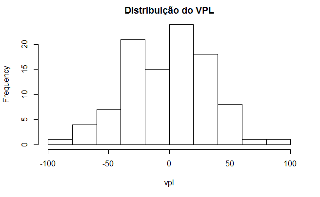

```r
# Ajustando o Gráfico para 3 imagens:
# par(mfrow=c(1,3))
# Vendo a Distribuição do VPL
hist(vpl,main="Distribuição do VPL")
```

CBR…

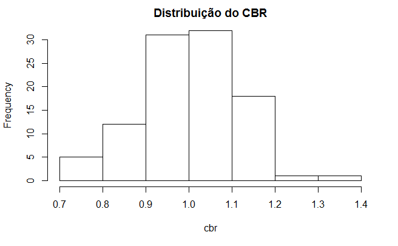

```r
# Vendo a Distribuição do CBR
hist(cbr,main="Distribuição do CBR")
```

ROI…

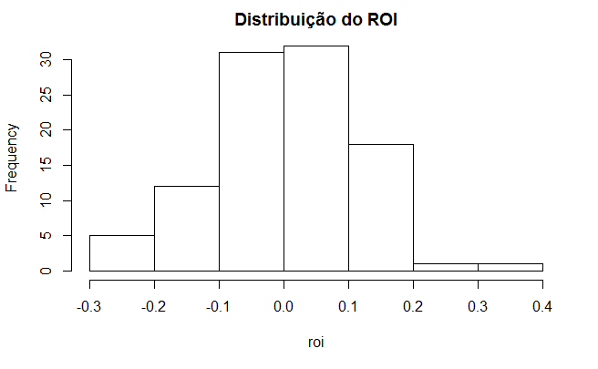

```r
# Vendo a Distribuição do CBR
hist(roi,main="Distribuição do ROI")
```

Assumindo que estes dados tem uma distribuição normal, vamos estimar agora os índices.

```r
# Ajustando o CBA para uma distribuição normal
cbr_fit = fitdist(cbr,"norm")
roi_fit = fitdist(roi,"norm")
vpl_fit = fitdist(vpl,"norm")
```

Vamos estimar o CBR!

```r
# Estimando o CBR
cbr_medio = as.numeric(cbr_fit$estimate[["mean"]])
cbr_medio = round(cbr_medio, digits=2)
cat("Para cada 1 real investido em SST, retornam em média ", cbr_medio, " Reais.")
```

```
Para cada 1 real investido em SST, retornam em média  1  Reais.
```

Podemos calcular um intervalo de confiança!

```r
confint(cbr_fit)
```

```
          2.5 %    97.5 %
mean 0.98115567 1.0234057
sd   0.09285073 0.1227144
```

Vamos estimar o ROI!

```r
# Estimando o ROI
roi_medio = as.numeric(roi_fit$estimate[["mean"]])*100
roi_medio = round(roi_medio,digits = 2)
cat("O retorno sobre investimento esperado é de ", roi_medio, " %.")
```

```
O retorno sobre investimento esperado é de  0.23  %.
```

Podemos calcular um intervalo de confiança!

```r
confint(roi_fit)
```

```
           2.5 %     97.5 %
mean -0.01884433 0.02340566
sd    0.09285073 0.12271441
```

Vamos estimar o VPL!

```r
# Informando o VPL
vpl_medio = as.numeric(vpl_fit$estimate[["mean"]])
vpl_medio = round(vpl_medio,digits = 2)
cat("O Valor Presente Líquido do Investimento esperado é ", vpl_medio, " Reais.")
```

```
O Valor Presente Líquido do Investimento esperado é  0.17  Reais.
```

Podemos calcular um intervalo de confiança!

```r
confint(vpl_fit)
```

```
         2.5 %    97.5 %
mean -6.173046  6.504515
sd   27.859119 36.823509
```

Feito, temos um protótipio de análise probabilística do CBA!